# The Many Variables & Spurious Waffles

Since most correlations do not indicate causal relationships, we need tools for distinguishing mere assoication from evidence of causation.

A confound is a variable that may be correlated with another variable of interest.

Multiple regressions * Statistical control for confounds

```r
library(rethinking)
library(dagitty)
data(WaffleDivorce)
d <- WaffleDivorce
# standardize variables
d$A <- scale( d$MedianAgeMarriage )
d$D <- scale( d$Divorce )
```

```r
sd(d$MedianAgeMarriage)
```

```
[1] 1.24363
```

```r
m5.1 <- quap(
alist(
D ~ dnorm( mu , sigma ) ,
mu <- a + bA * A ,
a ~ dnorm( 0 , 0.2 ) ,
bA ~ dnorm( 0 , 0.5 ) ,
sigma ~ dexp( 1 )
) , data = d )
```

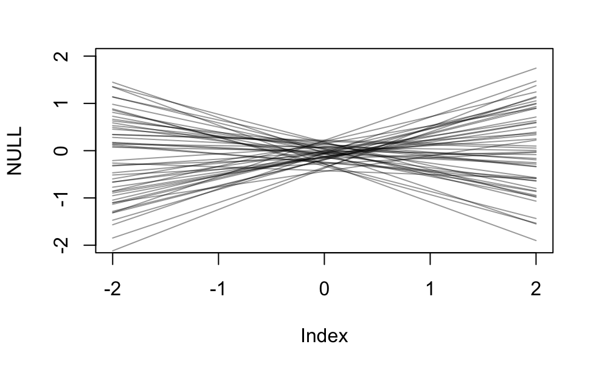

```r
set.seed(10)
prior <- extract.prior( m5.1 )
mu <- link( m5.1 , post=prior , data=list( A=c(-2,2) ) )
plot( NULL , xlim=c(-2,2) , ylim=c(-2,2) )
for ( i in 1:50 ) lines( c(-2,2) , mu[i,] , col=col.alpha("black",0.4) )
```

```r
A_seq <- seq( from=-3 , to=3.2 , length.out=30 )
mu <- link( m5.1 , data=list(A=A_seq) )
mu.mean <- apply( mu , 2, mean )
mu.PI <- apply( mu , 2 , PI )
# plot it all
plot( D ~ A , data=d , col=rangi2 )
lines( A_seq , mu.mean , lwd=2 )
```

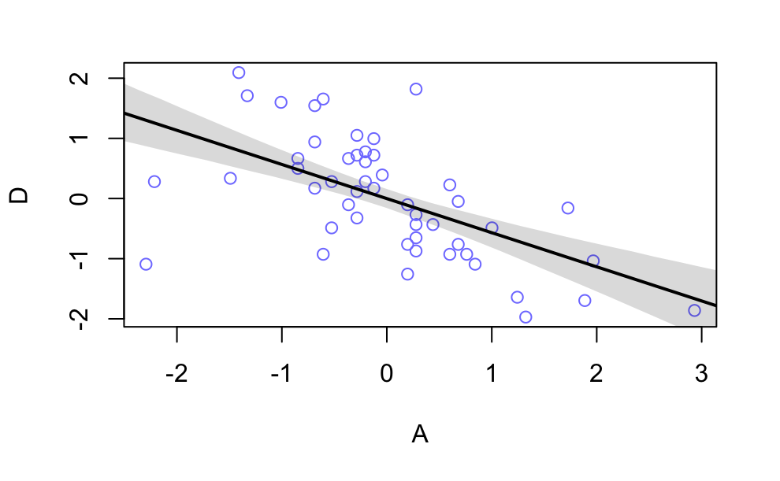

```r
shade( mu.PI , A_seq )
```

```r
d$M <- scale( d$Marriage )

m5.2 <- quap(
alist(
D ~ dnorm( mu , sigma ) ,
mu <- a + bM * M ,
a ~ dnorm( 0 , 0.2 ) ,
bM ~ dnorm( 0 , 0.5 ) ,
sigma ~ dexp( 1 )
) , data = d )
```

### 5.1.1 Think before you regress

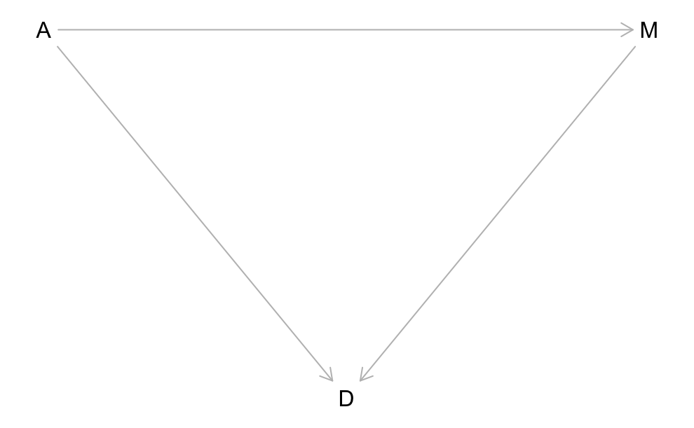

```r
dag5.1 <- dagitty( "dag {
A -> D
A -> M
M -> D
}")
coordinates(dag5.1) <- list( x=c(A=0,D=1,M=2) , y=c(A=0,D=1,M=0) )
plot( dag5.1 )
```

# 5.1.2 Multiple Regression Notation

1. Nominate the predictor variables you want in the linear model of the mean
2. For each predictor, make a parameter that will measure its association with the outcome
3. Multiply the parameter by the variable and add that term to the linear model

Linear models can be written in a compact fom like:

$$\mu_i=\alpha+\sum_{j=1}^{n}\beta_jx_{ji}$$
or
$$m=Xb$$
### 5.1.3 Approximating the posterior

```r
m5.3 <- quap(
alist(
D ~ dnorm( mu , sigma ) ,
mu <- a + bM*M + bA*A ,
a ~ dnorm( 0 , 0.2 ) ,
bM ~ dnorm( 0 , 0.5 ) ,
bA ~ dnorm( 0 , 0.5 ) ,
sigma ~ dexp( 1 )
) , data = d )
precis( m5.3 )
```

|  | mean | sd | 5.5% | 94.5% |
| --- | --- | --- | --- | --- |
| a | 0.00 | 0.10 | -0.16 | 0.16 |
| bM | -0.07 | 0.15 | -0.31 | 0.18 |
| bA | -0.61 | 0.15 | -0.85 | -0.37 |
| sigma | 0.79 | 0.08 | 0.66 | 0.91 |

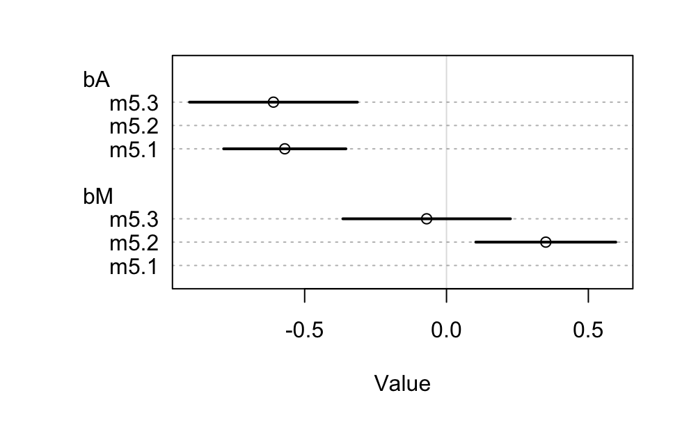

```r
a <- coeftab(m5.1,m5.2,m5.3)
coeftab_plot(a , par=c("bA","bM") )
```

I think there is a very important piece of what we are trying to do when tweezing out what variables are running the show. Here we have run the 3 regressions against each other and looking at their posteriors for each of the models.

- m5.1 is looking at age
- m5.2 is looking at marriage rate
- m5.3 is looking at both age and marriage rate

After we run the plot above for each of the models we are able to see that the effect that age doesn’t change outside of the variance. Thus… once we know median age of marriage for a state, there is little or no additional predictive power in also knowing the rate of marriage in that state.

### 5.1.4 Plotting multivariable posteriors

1. Predictor residual plots. These plots show the outcome against residual predictor values.
2. Counterfactual plots. These show the implied predictions for imaginary experiments in which the different predictor variables can be changed independently of one another.
3. Posterior prediction plots. These show model-based predictions against raw data, or otherwise display the error in prediction.

### 5.1.4.1 Predictor residual plots

```r
m5.4 <- quap(
alist(
M ~ dnorm( mu , sigma ) ,
mu <- a + bAM * A ,
a ~ dnorm( 0 , 0.2 ) ,
bAM ~ dnorm( 0 , 0.5 ) ,
sigma ~ dexp( 1 )
) , data = d )
```

```r
mu <- link(m5.4)
mu_mean <- apply( mu , 2 , mean )
mu_resid <- d$M - mu_mean
```

5.1.4.2 Counterfactual Plot

```r
# prepare new counterfactual data
M_seq <- seq( from=-2 , to=3 , length.out=30 )
pred_data <- data.frame( M = M_seq , A = 0 )
# compute counterfactual mean divorce (mu)
mu <- link( m5.3 , data=pred_data )
mu_mean <- apply( mu , 2 , mean )
mu_PI <- apply( mu , 2 , PI )
# simulate counterfactual divorce outcomes
D_sim <- sim( m5.3 , data=pred_data , n=1e4 )
D_PI <- apply( D_sim , 2 , PI )
# display predictions, hiding raw data with type="n"
plot( D ~ M , data=d , type="n" )
mtext( "Median age marriage (std) = 0" )
```

```r
lines( M_seq , mu_mean )
shade( mu_PI , M_seq )
```

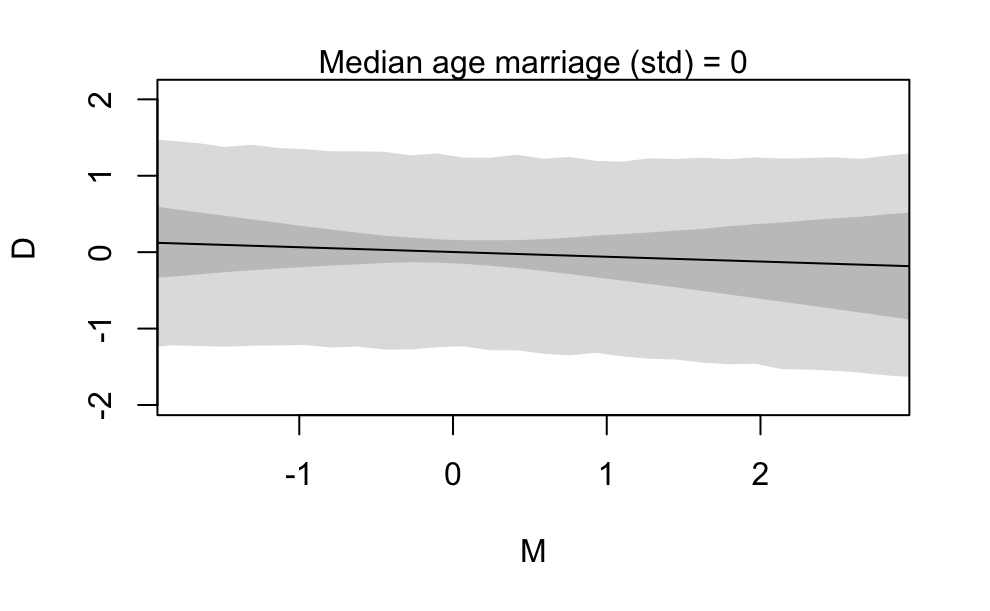

```r
shade( D_PI , M_seq )
```

The strategy above is to build a new list of data that describe the counterfactual cases we wish to simulate predictions for.

### 5.1.4.3 Posterior prediction plots

```r
# call link without specifying new data
# so it uses original data
mu <- link( m5.3 )
# summarize samples across cases
mu_mean <- apply( mu , 2 , mean )
mu_PI <- apply( mu , 2 , PI )
# simulate observations
# again no new data, so uses original data
D_sim <- sim( m5.3 , n=1e4 )
D_PI <- apply( D_sim , 2 , PI )

plot( mu_mean ~ d$D , col=rangi2 , ylim=range(mu_PI) ,
xlab="Observed divorce" , ylab="Predicted divorce" )
abline( a=0 , b=1 , lty=2 )
```

[output not shown]

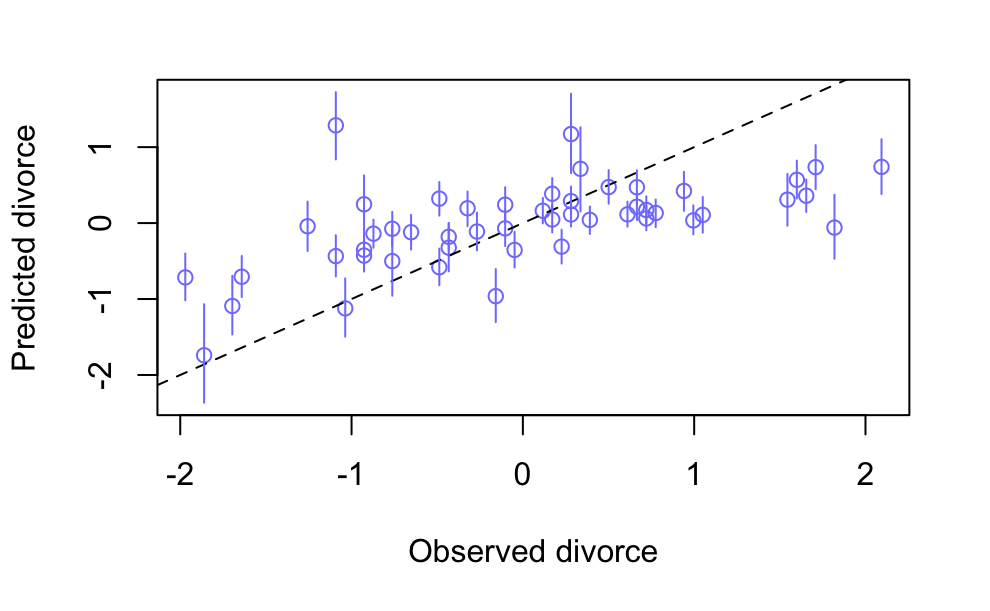

```r
for ( i in 1:nrow(d) ) lines( rep(d$D[i],2) , mu_PI[,i] , col=rangi2 )

identify( x=d$D , y=mu_mean , labels=d$Loc )
```

In this example, the difficulty of separately manipulating marriage rate and marriage age doesn’t impede inference much, only because marriage rate has almost no effect on prediction, once median age of marriage is taken into account.

## Simulation spurious association

```r
N <- 100 # number of cases
x_real <- rnorm( N ) # x_real as Gaussian with mean 0 and stddev 1
x_spur <- rnorm( N , x_real ) # x_spur as Gaussian with mean=x_real
y <- rnorm( N , x_real ) # y as Gaussian with mean=x_real
d <- data.frame(y,x_real,x_spur) # bind all together in data frame
d
```

| y | x_real | x_spur |
| --- | --- | --- |
| -0.5647853 | 1.301142445 | 2.230190377 |
| 0.4040340 | -0.380092819 | 0.309808034 |
| 0.6779139 | -0.067300861 | -0.483833055 |
| -1.1748443 | -1.660207746 | -2.047516224 |
| -0.2606075 | -1.369082003 | -0.184002238 |
| -1.0289219 | 0.603226962 | 0.971193542 |
| -1.2953891 | -0.058846301 | -0.965639731 |
| -1.4429205 | -0.526309782 | -0.912219033 |
| 3.1105810 | 1.096200326 | 0.479669973 |
| 1.6028801 | 0.122307984 | 0.015334344 |

[output cut: 90 more lines]

## 5.2 Masked relationship

```r
data(milk)
d <- milk
str(d)
```

```
'data.frame':   29 obs. of  8 variables:
 $ clade         : Factor w/ 4 levels "Ape","New World Monkey",..: 4 4 4 4 4 2 2 2 2 2 ...
 $ species       : Factor w/ 29 levels "A palliata","Alouatta seniculus",..: 11 8 9 10 16 2 1 6 28 27 ...
 $ kcal.per.g    : num  0.49 0.51 0.46 0.48 0.6 0.47 0.56 0.89 0.91 0.92 ...
 $ perc.fat      : num  16.6 19.3 14.1 14.9 27.3 ...
 $ perc.protein  : num  15.4 16.9 16.9 13.2 19.5 ...
 $ perc.lactose  : num  68 63.8 69 71.9 53.2 ...
 $ mass          : num  1.95 2.09 2.51 1.62 2.19 5.25 5.37 2.51 0.71 0.68 ...
 $ neocortex.perc: num  55.2 NA NA NA NA ...
```

```r
# Scale the information between the datapoints in order to create a dataset ready to model on
d$K <- scale(d$kcal.per.g)
d$N <- scale(d$neocortex.perc)
d$M <- scale(log(d$mass))
```

First model to onsider the simple bivariate regression between kilocalories and neocortex percent.
$$K_i~Normal(\mu_i,\sigma)$$
$$\mu_i =\alpha+\beta_NN_i$$

```r
m5.5_draft <- quap(
alist(
K ~ dnorm( mu , sigma ) ,
mu <- a + bN*N ,
a ~ dnorm( 0 , 1 ) ,
bN ~ dnorm( 0 , 1 ) ,
sigma ~ dexp( 1 )
) , data=d )
```

```
Error in quap(alist(K ~ dnorm(mu, sigma), mu <- a + bN * N, a ~ dnorm(0,  :
The start values for the parameters were invalid. This could be caused by missing values (NA) in the data or by start values outside the parameter constraints. If there are no NA values in the data, try using explicit start values.
```

```r
d$neocortex.perc
```

```
 [1] 55.16    NA    NA    NA    NA 64.54 64.54 67.64    NA 68.85 58.85 61.69 60.32
[14]    NA    NA 69.97    NA 70.41    NA 73.40    NA 67.53    NA 71.26 72.60    NA
[27] 70.24 76.30 75.49
```

There are missing values

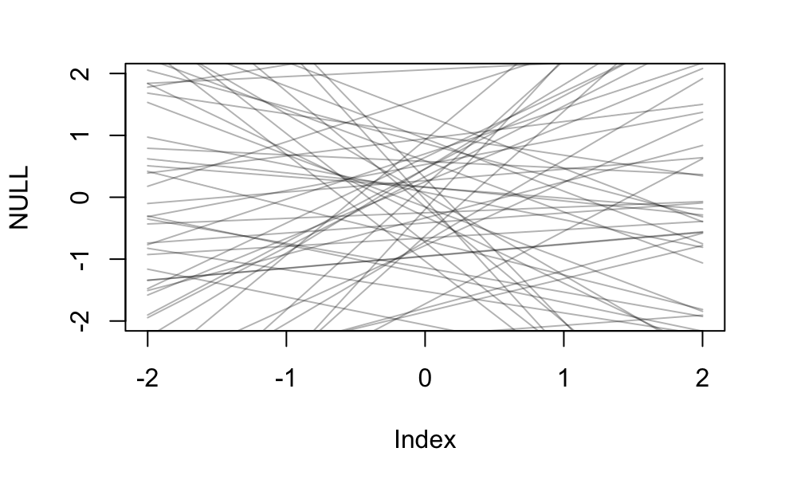

```r
prior <- extract.prior( m5.5_draft )
xseq <- c(-2,2)
mu <- link( m5.5_draft , post=prior , data=list(N=xseq) )
plot( NULL , xlim=xseq , ylim=xseq )
for ( i in 1:50 ) lines( xseq , mu[i,] , col=col.alpha("black",0.3) )
```

```r
m5.5 <- quap(
alist(
K ~ dnorm( mu , sigma ) ,
mu <- a + bN*N ,
a ~ dnorm( 0 , 0.2 ) ,
bN ~ dnorm( 0 , 0.5 ) ,
sigma ~ dexp( 1 )
) , data=dcc )
```

|  | mean | sd | 5.5% | 94.5% |
| --- | --- | --- | --- | --- |
| a | 0.04 | 0.15 | -0.21 | 0.29 |
| bN | 0.13 | 0.22 | -0.22 | 0.49 |
| sigma | 1.00 | 0.16 | 0.74 | 1.26 |

```r
xseq <- seq( from=min(dcc$N)-0.15 , to=max(dcc$N)+0.15 , length.out=30 )
mu <- link( m5.5 , data=list(N=xseq) )
mu_mean <- apply(mu,2,mean)
mu_PI <- apply(mu,2,PI)
plot( K ~ N , data=dcc )
lines( xseq , mu_mean , lwd=2 )
```